# Работа с данными: задания

Зарманбетов Ахмед

Установим и подгрузим пакеты, которые нам будут нужны для работы.

```r
# packages <- c('readr', 'dplyr', 'ggplot2', 'tidyr', 'lubridate', 'stringr', 'naniar')
# install.packages(packages)
library(readr)
library(dplyr)
library(ggplot2)
library(tidyr)
library(lubridate)
library(stringr)
library(naniar)
```

Рассмотрим набор данных `weather`.

```r
weather <- read_csv2('data/weather.csv')
glimpse(weather)
```

```
## Observations: 286
## Variables: 35
## $ X       <dbl> 1, 2, 3, 4, 5, 6, 7, 8, 9, 10, 11, 12, 13, 14, 15, 16, 1…
## $ year    <dbl> 2014, 2014, 2014, 2014, 2014, 2014, 2014, 2014, 2014, 20…
## $ month   <dbl> 12, 12, 12, 12, 12, 12, 12, 12, 12, 12, 12, 12, 12, 12, …
## $ measure <chr> "Max.TemperatureF", "Mean.TemperatureF", "Min.Temperatur…
## $ X1      <chr> "64", "52", "39", "46", "40", "26", "74", "63", "52", "3…
## $ X2      <chr> "42", "38", "33", "40", "27", "17", "92", "72", "51", "3…
## $ X3      <chr> "51", "44", "37", "49", "42", "24", "100", "79", "57", "…
## $ X4      <chr> "43", "37", "30", "24", "21", "13", "69", "54", "39", "3…
## $ X5      <chr> "42", "34", "26", "37", "25", "12", "85", "66", "47", "3…
## $ X6      <chr> "45", "42", "38", "45", "40", "36", "100", "93", "85", "…
## $ X7      <chr> "38", "30", "21", "36", "20", "-3", "92", "61", "29", "3…
## $ X8      <chr> "29", "24", "18", "28", "16", "3", "92", "70", "47", "30…
## $ X9      <chr> "49", "39", "29", "49", "41", "28", "100", "93", "86", "…
```

[output cut: 22 more lines]

- Преобразуйте дни месяца в переменную `day`. Что может пойти не так? Попробуйте посмотреть дополнительные аргументы функции, которую вы используете для решения этой задачи.

Параметр `na.rm = TRUE` убирает строки с пропущенными значениями(`NA`). Такие значения появляются, так как, например, для февраля может быть только 28 значений.

```r
weather2 <- weather %>%
  gather(day, value, paste0('X',1:31), na.rm = TRUE)
head(weather2)
```

| X | year | month | measure | day | value |
| --- | --- | --- | --- | --- | --- |
| 1 | 2014 | 12 | Max.TemperatureF | X1 | 64 |
| 2 | 2014 | 12 | Mean.TemperatureF | X1 | 52 |
| 3 | 2014 | 12 | Min.TemperatureF | X1 | 39 |
| 4 | 2014 | 12 | Max.Dew.PointF | X1 | 46 |
| 5 | 2014 | 12 | MeanDew.PointF | X1 | 40 |
| 6 | 2014 | 12 | Min.DewpointF | X1 | 26 |

- Есть ли ненужные переменные? Если есть, то удалите их.

Столбец `X` это просто индекс наблюдения. Он нам ничего не дает, поэтому удалим его.

```r
weather2 <- weather2 %>%
  select(-X)
head(weather2)
```

| year | month | measure | day | value |
| --- | --- | --- | --- | --- |
| 2014 | 12 | Max.TemperatureF | X1 | 64 |
| 2014 | 12 | Mean.TemperatureF | X1 | 52 |
| 2014 | 12 | Min.TemperatureF | X1 | 39 |
| 2014 | 12 | Max.Dew.PointF | X1 | 46 |
| 2014 | 12 | MeanDew.PointF | X1 | 40 |
| 2014 | 12 | Min.DewpointF | X1 | 26 |

- Что не так с переменной `measure`? Исправьте это.

```r
weather3 <- weather2 %>%
              spread(measure, value)
```

- В колонке `day` стоит перед каждым днём *X*. Уберите его и приведите переменную к числовому типу.

```r
weather4 <- weather3 %>%
              mutate(day = str_replace(day,'X',''))
head(weather4)
```

| year | month | day | CloudCover | Events | Max.Dew.PointF | Max.Gust.SpeedMPH | Max.Humidity | Max.Sea.Level.PressureIn | Max.TemperatureF | Max.VisibilityMiles | Max.Wind.SpeedMPH | Mean.Humidity | Mean.Sea.Level.PressureIn | Mean.TemperatureF | Mean.VisibilityMiles | Mean.Wind.SpeedMPH | MeanDew.PointF | Min.DewpointF | Min.Humidity | Min.Sea.Level.PressureIn | Min.TemperatureF | Min.VisibilityMiles | PrecipitationIn | WindDirDegrees |
| --- | --- | --- | --- | --- | --- | --- | --- | --- | --- | --- | --- | --- | --- | --- | --- | --- | --- | --- | --- | --- | --- | --- | --- | --- |
| 2014 | 12 | 1 | 6 | Rain | 46 | 29 | 74 | 30.45 | 64 | 10 | 22 | 63 | 30.13 | 52 | 10 | 13 | 40 | 26 | 52 | 30.01 | 39 | 10 | 0.01 | 268 |
| 2014 | 12 | 10 | 8 | Rain | 45 | 29 | 100 | 29.58 | 48 | 10 | 23 | 95 | 29.5 | 43 | 3 | 13 | 39 | 37 | 89 | 29.43 | 38 | 1 | 0.28 | 357 |
| 2014 | 12 | 11 | 8 | Rain-Snow | 37 | 28 | 92 | 29.81 | 39 | 10 | 21 | 87 | 29.61 | 36 | 7 | 13 | 31 | 27 | 82 | 29.44 | 32 | 1 | 0.02 | 230 |
| 2014 | 12 | 12 | 7 | Snow | 28 | 21 | 85 | 29.88 | 39 | 10 | 16 | 75 | 29.85 | 35 | 10 | 11 | 27 | 25 | 64 | 29.81 | 31 | 7 | T | 286 |
| 2014 | 12 | 13 | 5 | NA | 28 | 23 | 75 | 29.86 | 42 | 10 | 17 | 65 | 29.82 | 37 | 10 | 12 | 26 | 24 | 55 | 29.78 | 32 | 10 | T | 298 |
| 2014 | 12 | 14 | 4 | NA | 29 | 20 | 82 | 29.91 | 45 | 10 | 15 | 68 | 29.83 | 39 | 10 | 10 | 27 | 25 | 53 | 29.78 | 33 | 10 | 0.00 | 306 |

- Хотелось бы получить одну переменную с датой. Сделайте это двумя способами.

**1 способ**

```r
weather5 <- weather4 %>%
              unite(date, year, month, day, sep = "-") %>%
              mutate(date = ymd(date))
head(weather5)
```

| date | CloudCover | Events | Max.Dew.PointF | Max.Gust.SpeedMPH | Max.Humidity | Max.Sea.Level.PressureIn | Max.TemperatureF | Max.VisibilityMiles | Max.Wind.SpeedMPH | Mean.Humidity | Mean.Sea.Level.PressureIn | Mean.TemperatureF | Mean.VisibilityMiles | Mean.Wind.SpeedMPH | MeanDew.PointF | Min.DewpointF | Min.Humidity | Min.Sea.Level.PressureIn | Min.TemperatureF | Min.VisibilityMiles | PrecipitationIn | WindDirDegrees |
| --- | --- | --- | --- | --- | --- | --- | --- | --- | --- | --- | --- | --- | --- | --- | --- | --- | --- | --- | --- | --- | --- | --- |
| 2014-12-01 | 6 | Rain | 46 | 29 | 74 | 30.45 | 64 | 10 | 22 | 63 | 30.13 | 52 | 10 | 13 | 40 | 26 | 52 | 30.01 | 39 | 10 | 0.01 | 268 |
| 2014-12-10 | 8 | Rain | 45 | 29 | 100 | 29.58 | 48 | 10 | 23 | 95 | 29.5 | 43 | 3 | 13 | 39 | 37 | 89 | 29.43 | 38 | 1 | 0.28 | 357 |
| 2014-12-11 | 8 | Rain-Snow | 37 | 28 | 92 | 29.81 | 39 | 10 | 21 | 87 | 29.61 | 36 | 7 | 13 | 31 | 27 | 82 | 29.44 | 32 | 1 | 0.02 | 230 |
| 2014-12-12 | 7 | Snow | 28 | 21 | 85 | 29.88 | 39 | 10 | 16 | 75 | 29.85 | 35 | 10 | 11 | 27 | 25 | 64 | 29.81 | 31 | 7 | T | 286 |
| 2014-12-13 | 5 | NA | 28 | 23 | 75 | 29.86 | 42 | 10 | 17 | 65 | 29.82 | 37 | 10 | 12 | 26 | 24 | 55 | 29.78 | 32 | 10 | T | 298 |
| 2014-12-14 | 4 | NA | 29 | 20 | 82 | 29.91 | 45 | 10 | 15 | 68 | 29.83 | 39 | 10 | 10 | 27 | 25 | 53 | 29.78 | 33 | 10 | 0.00 | 306 |

**2 способ**

```r
weather5 <- weather4 %>%
              mutate(date = make_date(year, month, day))
head(weather5)
```

| year | month | day | CloudCover | Events | Max.Dew.PointF | Max.Gust.SpeedMPH | Max.Humidity | Max.Sea.Level.PressureIn | Max.TemperatureF | Max.VisibilityMiles | Max.Wind.SpeedMPH | Mean.Humidity | Mean.Sea.Level.PressureIn | Mean.TemperatureF | Mean.VisibilityMiles | Mean.Wind.SpeedMPH | MeanDew.PointF | Min.DewpointF | Min.Humidity | Min.Sea.Level.PressureIn | Min.TemperatureF | Min.VisibilityMiles | PrecipitationIn | WindDirDegrees | date |
| --- | --- | --- | --- | --- | --- | --- | --- | --- | --- | --- | --- | --- | --- | --- | --- | --- | --- | --- | --- | --- | --- | --- | --- | --- | --- |
| 2014 | 12 | 1 | 6 | Rain | 46 | 29 | 74 | 30.45 | 64 | 10 | 22 | 63 | 30.13 | 52 | 10 | 13 | 40 | 26 | 52 | 30.01 | 39 | 10 | 0.01 | 268 | 2014-12-01 |
| 2014 | 12 | 10 | 8 | Rain | 45 | 29 | 100 | 29.58 | 48 | 10 | 23 | 95 | 29.5 | 43 | 3 | 13 | 39 | 37 | 89 | 29.43 | 38 | 1 | 0.28 | 357 | 2014-12-10 |
| 2014 | 12 | 11 | 8 | Rain-Snow | 37 | 28 | 92 | 29.81 | 39 | 10 | 21 | 87 | 29.61 | 36 | 7 | 13 | 31 | 27 | 82 | 29.44 | 32 | 1 | 0.02 | 230 | 2014-12-11 |
| 2014 | 12 | 12 | 7 | Snow | 28 | 21 | 85 | 29.88 | 39 | 10 | 16 | 75 | 29.85 | 35 | 10 | 11 | 27 | 25 | 64 | 29.81 | 31 | 7 | T | 286 | 2014-12-12 |
| 2014 | 12 | 13 | 5 | NA | 28 | 23 | 75 | 29.86 | 42 | 10 | 17 | 65 | 29.82 | 37 | 10 | 12 | 26 | 24 | 55 | 29.78 | 32 | 10 | T | 298 | 2014-12-13 |
| 2014 | 12 | 14 | 4 | NA | 29 | 20 | 82 | 29.91 | 45 | 10 | 15 | 68 | 29.83 | 39 | 10 | 10 | 27 | 25 | 53 | 29.78 | 33 | 10 | 0.00 | 306 | 2014-12-14 |

- Получите день недели для каждой даты.

```r
weather6 <- weather5 %>%
              mutate(wd = wday(date))
head(weather6)
```

| year | month | day | CloudCover | Events | Max.Dew.PointF | Max.Gust.SpeedMPH | Max.Humidity | Max.Sea.Level.PressureIn | Max.TemperatureF | Max.VisibilityMiles | Max.Wind.SpeedMPH | Mean.Humidity | Mean.Sea.Level.PressureIn | Mean.TemperatureF | Mean.VisibilityMiles | Mean.Wind.SpeedMPH | MeanDew.PointF | Min.DewpointF | Min.Humidity | Min.Sea.Level.PressureIn | Min.TemperatureF | Min.VisibilityMiles | PrecipitationIn | WindDirDegrees | date | wd |
| --- | --- | --- | --- | --- | --- | --- | --- | --- | --- | --- | --- | --- | --- | --- | --- | --- | --- | --- | --- | --- | --- | --- | --- | --- | --- | --- |
| 2014 | 12 | 1 | 6 | Rain | 46 | 29 | 74 | 30.45 | 64 | 10 | 22 | 63 | 30.13 | 52 | 10 | 13 | 40 | 26 | 52 | 30.01 | 39 | 10 | 0.01 | 268 | 2014-12-01 | 2 |
| 2014 | 12 | 10 | 8 | Rain | 45 | 29 | 100 | 29.58 | 48 | 10 | 23 | 95 | 29.5 | 43 | 3 | 13 | 39 | 37 | 89 | 29.43 | 38 | 1 | 0.28 | 357 | 2014-12-10 | 4 |
| 2014 | 12 | 11 | 8 | Rain-Snow | 37 | 28 | 92 | 29.81 | 39 | 10 | 21 | 87 | 29.61 | 36 | 7 | 13 | 31 | 27 | 82 | 29.44 | 32 | 1 | 0.02 | 230 | 2014-12-11 | 5 |
| 2014 | 12 | 12 | 7 | Snow | 28 | 21 | 85 | 29.88 | 39 | 10 | 16 | 75 | 29.85 | 35 | 10 | 11 | 27 | 25 | 64 | 29.81 | 31 | 7 | T | 286 | 2014-12-12 | 6 |
| 2014 | 12 | 13 | 5 | NA | 28 | 23 | 75 | 29.86 | 42 | 10 | 17 | 65 | 29.82 | 37 | 10 | 12 | 26 | 24 | 55 | 29.78 | 32 | 10 | T | 298 | 2014-12-13 | 7 |
| 2014 | 12 | 14 | 4 | NA | 29 | 20 | 82 | 29.91 | 45 | 10 | 15 | 68 | 29.83 | 39 | 10 | 10 | 27 | 25 | 53 | 29.78 | 33 | 10 | 0.00 | 306 | 2014-12-14 | 1 |

- Обратим внимание на переменную `PrecipitationIn`. Выведите уникальные значения этой переменной. Видим, что есть непонятное значение `T`. Оно означает очень низкое значение, поэтому замените его 0.

```r
weather6 %>%
  select(PrecipitationIn) %>%
  arrange(desc(PrecipitationIn)) %>%
  unique() %>%
  head()
```

| PrecipitationIn |
| --- |
| T |
| 2.90 |
| 2.46 |
| 1.72 |
| 1.43 |
| 1.12 |

```r
weather7 <- weather6 %>%
              mutate(PrecipitationIn = str_replace(PrecipitationIn, 'T','0'))
head(weather7)
```

| year | month | day | CloudCover | Events | Max.Dew.PointF | Max.Gust.SpeedMPH | Max.Humidity | Max.Sea.Level.PressureIn | Max.TemperatureF | Max.VisibilityMiles | Max.Wind.SpeedMPH | Mean.Humidity | Mean.Sea.Level.PressureIn | Mean.TemperatureF | Mean.VisibilityMiles | Mean.Wind.SpeedMPH | MeanDew.PointF | Min.DewpointF | Min.Humidity | Min.Sea.Level.PressureIn | Min.TemperatureF | Min.VisibilityMiles | PrecipitationIn | WindDirDegrees | date | wd |
| --- | --- | --- | --- | --- | --- | --- | --- | --- | --- | --- | --- | --- | --- | --- | --- | --- | --- | --- | --- | --- | --- | --- | --- | --- | --- | --- |
| 2014 | 12 | 1 | 6 | Rain | 46 | 29 | 74 | 30.45 | 64 | 10 | 22 | 63 | 30.13 | 52 | 10 | 13 | 40 | 26 | 52 | 30.01 | 39 | 10 | 0.01 | 268 | 2014-12-01 | 2 |
| 2014 | 12 | 10 | 8 | Rain | 45 | 29 | 100 | 29.58 | 48 | 10 | 23 | 95 | 29.5 | 43 | 3 | 13 | 39 | 37 | 89 | 29.43 | 38 | 1 | 0.28 | 357 | 2014-12-10 | 4 |
| 2014 | 12 | 11 | 8 | Rain-Snow | 37 | 28 | 92 | 29.81 | 39 | 10 | 21 | 87 | 29.61 | 36 | 7 | 13 | 31 | 27 | 82 | 29.44 | 32 | 1 | 0.02 | 230 | 2014-12-11 | 5 |
| 2014 | 12 | 12 | 7 | Snow | 28 | 21 | 85 | 29.88 | 39 | 10 | 16 | 75 | 29.85 | 35 | 10 | 11 | 27 | 25 | 64 | 29.81 | 31 | 7 | 0 | 286 | 2014-12-12 | 6 |
| 2014 | 12 | 13 | 5 | NA | 28 | 23 | 75 | 29.86 | 42 | 10 | 17 | 65 | 29.82 | 37 | 10 | 12 | 26 | 24 | 55 | 29.78 | 32 | 10 | 0 | 298 | 2014-12-13 | 7 |
| 2014 | 12 | 14 | 4 | NA | 29 | 20 | 82 | 29.91 | 45 | 10 | 15 | 68 | 29.83 | 39 | 10 | 10 | 27 | 25 | 53 | 29.78 | 33 | 10 | 0.00 | 306 | 2014-12-14 | 1 |

- Посмотрите на структуру таблички. Какие типы у ваших переменных? Измените эти типы. Попробуйте использовать функцию `mutate_at`.

```r
glimpse(weather7)
```

```
## Observations: 366
## Variables: 27
## $ year                      <dbl> 2014, 2014, 2014, 2014, 2014, 2014, 20…
## $ month                     <dbl> 12, 12, 12, 12, 12, 12, 12, 12, 12, 12…
## $ day                       <chr> "1", "10", "11", "12", "13", "14", "15…
## $ CloudCover                <chr> "6", "8", "8", "7", "5", "4", "2", "8"…
## $ Events                    <chr> "Rain", "Rain", "Rain-Snow", "Snow", N…
## $ Max.Dew.PointF            <chr> "46", "45", "37", "28", "28", "29", "3…
## $ Max.Gust.SpeedMPH         <chr> "29", "29", "28", "21", "23", "20", "2…
## $ Max.Humidity              <chr> "74", "100", "92", "85", "75", "82", "…
## $ Max.Sea.Level.PressureIn  <chr> "30.45", "29.58", "29.81", "29.88", "2…
## $ Max.TemperatureF          <chr> "64", "48", "39", "39", "42", "45", "4…
## $ Max.VisibilityMiles       <chr> "10", "10", "10", "10", "10", "10", "1…
## $ Max.Wind.SpeedMPH         <chr> "22", "23", "21", "16", "17", "15", "1…
## $ Mean.Humidity             <chr> "63", "95", "87", "75", "65", "68", "7…
## $ Mean.Sea.Level.PressureIn <chr> "30.13", "29.5", "29.61", "29.85", "29…
## $ Mean.TemperatureF         <chr> "52", "43", "36", "35", "37", "39", "3…
## $ Mean.VisibilityMiles      <chr> "10", "3", "7", "10", "10", "10", "10"…
## $ Mean.Wind.SpeedMPH        <chr> "13", "13", "13", "11", "12", "10", "6…
## $ MeanDew.PointF            <chr> "40", "39", "31", "27", "26", "27", "2…
## $ Min.DewpointF             <chr> "26", "37", "27", "25", "24", "25", "2…
## $ Min.Humidity              <chr> "52", "89", "82", "64", "55", "53", "6…
## $ Min.Sea.Level.PressureIn  <chr> "30.01", "29.43", "29.44", "29.81", "2…
## $ Min.TemperatureF          <chr> "39", "38", "32", "31", "32", "33", "3…
## $ Min.VisibilityMiles       <chr> "10", "1", "1", "7", "10", "10", "10",…
## $ PrecipitationIn           <chr> "0.01", "0.28", "0.02", "0", "0", "0.0…
## $ WindDirDegrees            <chr> "268", "357", "230", "286", "298", "30…
## $ date                      <date> 2014-12-01, 2014-12-10, 2014-12-11, 2…
## $ wd                        <dbl> 2, 4, 5, 6, 7, 1, 2, 3, 4, 5, 6, 3, 7,…
```

```r
weather8 <- weather7 %>%
              mutate_at(vars(CloudCover:WindDirDegrees, - Events), as.numeric)
glimpse(weather8)
```

```
## Observations: 366
## Variables: 27
## $ year                      <dbl> 2014, 2014, 2014, 2014, 2014, 2014, 20…
## $ month                     <dbl> 12, 12, 12, 12, 12, 12, 12, 12, 12, 12…
## $ day                       <chr> "1", "10", "11", "12", "13", "14", "15…
## $ CloudCover                <dbl> 6, 8, 8, 7, 5, 4, 2, 8, 8, 7, 4, 7, 6,…
## $ Events                    <chr> "Rain", "Rain", "Rain-Snow", "Snow", N…
## $ Max.Dew.PointF            <dbl> 46, 45, 37, 28, 28, 29, 33, 42, 46, 34…
## $ Max.Gust.SpeedMPH         <dbl> 29, 29, 28, 21, 23, 20, 21, 10, 26, 30…
## $ Max.Humidity              <dbl> 74, 100, 92, 85, 75, 82, 89, 96, 100, …
## $ Max.Sea.Level.PressureIn  <dbl> 30.45, 29.58, 29.81, 29.88, 29.86, 29.…
## $ Max.TemperatureF          <dbl> 64, 48, 39, 39, 42, 45, 42, 44, 49, 44…
## $ Max.VisibilityMiles       <dbl> 10, 10, 10, 10, 10, 10, 10, 10, 10, 10…
## $ Max.Wind.SpeedMPH         <dbl> 22, 23, 21, 16, 17, 15, 15, 8, 20, 23,…
## $ Mean.Humidity             <dbl> 63, 95, 87, 75, 65, 68, 75, 85, 85, 73…
## $ Mean.Sea.Level.PressureIn <dbl> 30.13, 29.50, 29.61, 29.85, 29.82, 29.…
## $ Mean.TemperatureF         <dbl> 52, 43, 36, 35, 37, 39, 37, 40, 45, 40…
## $ Mean.VisibilityMiles      <dbl> 10, 3, 7, 10, 10, 10, 10, 9, 6, 10, 10…
## $ Mean.Wind.SpeedMPH        <dbl> 13, 13, 13, 11, 12, 10, 6, 4, 11, 14, …
## $ MeanDew.PointF            <dbl> 40, 39, 31, 27, 26, 27, 29, 36, 41, 30…
## $ Min.DewpointF             <dbl> 26, 37, 27, 25, 24, 25, 27, 30, 32, 26…
## $ Min.Humidity              <dbl> 52, 89, 82, 64, 55, 53, 60, 73, 70, 57…
## $ Min.Sea.Level.PressureIn  <dbl> 30.01, 29.43, 29.44, 29.81, 29.78, 29.…
## $ Min.TemperatureF          <dbl> 39, 38, 32, 31, 32, 33, 32, 35, 41, 36…
## $ Min.VisibilityMiles       <dbl> 10, 1, 1, 7, 10, 10, 10, 5, 1, 10, 10,…
## $ PrecipitationIn           <dbl> 0.01, 0.28, 0.02, 0.00, 0.00, 0.00, 0.…
## $ WindDirDegrees            <dbl> 268, 357, 230, 286, 298, 306, 324, 79,…
## $ date                      <date> 2014-12-01, 2014-12-10, 2014-12-11, 2…
## $ wd                        <dbl> 2, 4, 5, 6, 7, 1, 2, 3, 4, 5, 6, 3, 7,…
```

- Посмотрите на пропущенные значения. Выведите разные статистики. Что можно сделать с этими пропущенными значениями?

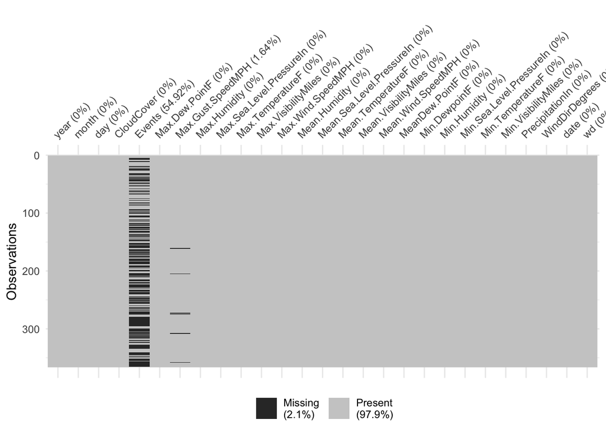

```r
vis_miss(weather8)
```

```r
miss_var_summary(weather8)
```

| variable | n_miss | pct_miss |
| --- | --- | --- |
| Events | 201 | 54.918033 |
| Max.Gust.SpeedMPH | 6 | 1.639344 |
| year | 0 | 0.000000 |
| month | 0 | 0.000000 |
| day | 0 | 0.000000 |
| CloudCover | 0 | 0.000000 |
| Max.Dew.PointF | 0 | 0.000000 |
| Max.Humidity | 0 | 0.000000 |
| Max.Sea.Level.PressureIn | 0 | 0.000000 |
| Max.TemperatureF | 0 | 0.000000 |

[output cut: 17 more lines]

```r
miss_case_summary(weather8)
```

| case | n_miss | pct_miss |
| --- | --- | --- |
| 205 | 2 | 7.407407 |
| 273 | 2 | 7.407407 |
| 275 | 2 | 7.407407 |
| 308 | 2 | 7.407407 |
| 358 | 2 | 7.407407 |
| 5 | 1 | 3.703704 |
| 6 | 1 | 3.703704 |
| 7 | 1 | 3.703704 |
| 11 | 1 | 3.703704 |
| 19 | 1 | 3.703704 |

[output cut: 356 more lines]

Переменная `Events` имеет очень много пропущенных значений, поэтому удалим эту переменную.

```r
weather9 <- weather8 %>%
              select(-Events)
```

Переменная `Max.Gust.SpeedMPH` имеет небольшое количество пропущенных значений. Мы можем удалить их или заменить средним.

```r
weather10 <-weather9 %>%
              drop_na()
```

```r
weather11 <-weather9 %>%
              impute_mean_at("Max.Gust.SpeedMPH")
```

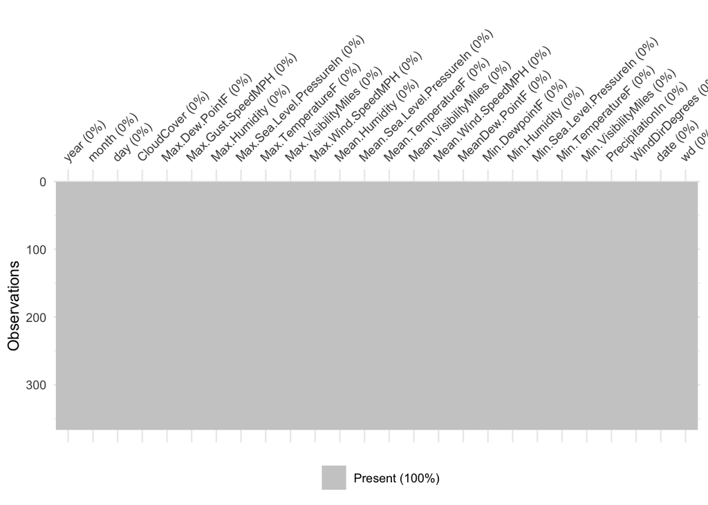

```r
vis_miss(weather11)
```